# Statistical Work Example

Benedikt Ströbl

February 16, 2022 | 22:34:49 | CET

```r
library(tidyverse)
library(tidymodels)
library(haven)
library(broom)
library(colorspace)
library(modelsummary)
library(flextable)
library(jtools)
library(specr)
library(kableExtra)
```

### Task 1 - Pruning the news feed [15 points in total]

In her article [“Pruning the news feed: Unfriending and unfollowing political content on social media” (Research & Politics 2016)](https://doi.org/10.1177/2053168016661873), Leticia Bode explores the extent to which users exercise control over their social media experiences, and who tends to engage in avoidance of political information by unfriending people who post about politics on social media. In the following, you are asked to reproduce some of her findings presented in the paper. To do so, check out the paper (accessible under the link above; ungated) and work with the dataset `bode-pew-data.sav` that you find in your assignment repository.

1. Reproduce **Figure 1**. Note that the corresponding variables in the dataset are named `ufptm`, `ufdo`, `ufa`, `ufdy`, `ufwo` (in the order that is shown in the original plot). The original plot has some bad/ugly features. When reproducing the figure, improve over the original design, and justify your design choices. [3 points]

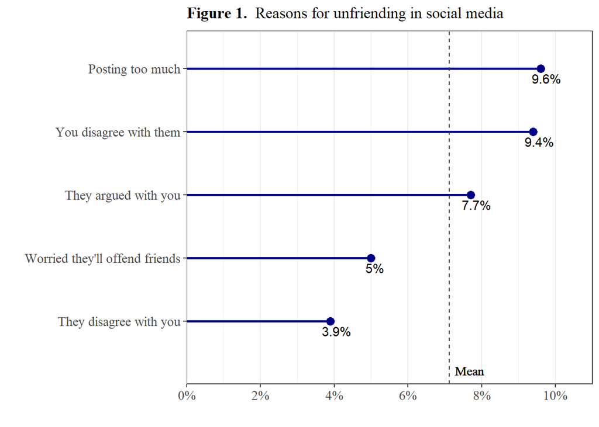

```r
# Load data as tibble
bode_pew_data <- as_tibble(read_sav("bode-pew-data.sav"))

# Select relevant columns, drop NA values and calculate percentage per column
df_bode_pew_data <- bode_pew_data %>%
  select(ufptm, ufdo, ufa, ufdy, ufwo) %>%
  drop_na() %>%
  summarise(across(everything(),
                   ~ sum(.) / n(),)) %>%
  # Rename columns to explicit labels
  rename(
    "Posting too much" = ufptm,
    "You disagree with them" = ufdo,
    "They argued with you" = ufa,
    "They disagree with you" = ufdy,
    "Worried they'll offend friends" = ufwo
  ) %>%
  # Convert tibble to a longer format for plotting
  pivot_longer(everything(),
               names_to = "var_name") %>%
  # Round value and transform to percentage
  mutate(value = round(value, 3))

# Plot: reorder columns by values and adding labels
df_bode_pew_data %>%
  ggplot(aes(
    x = value,
    xend = 0,
    y = reorder(var_name, value),
    yend = reorder(var_name, value),
    label = value
  )) +
  # Draw line
  geom_segment(size = 1,
               color = "darkblue") +
  # Plot lollipop heads
  geom_point(size = 3,
             color = "darkblue",) +
  # Plot labels
  geom_text(aes(label = paste0(value * 100, "%")),
            hjust = 0.3,
            vjust = 1.5) +
  # Plot mean line
  geom_vline(
    xintercept = mean(df_bode_pew_data$value),
    linetype = 2,
    colour = "grey20"
  ) +
  # Plot mean line label
  geom_text(aes(
    x = mean(value),
    y = 0,
    label = "Mean",
    hjust = -0.2,
    vjust = -1
  ),
  family = "serif") +
  # Labeling
  labs(
    x = "",
    y = "",
    title = expression(bold("Figure 1. ") ~ "Reasons for unfriending in social media")
  ) +
  # Set x-axis limits
  scale_x_continuous(
    labels = label_percent(1),
    expand = c(0, 0),
    limits = c(0, 0.11),
    breaks = seq(0, 0.13, 0.02)
  ) +
  # Some styling
  theme_bw() +
  theme(
    panel.grid.major.y = element_blank(),
    text = element_text(
      color = "black",
      family = "serif",
      size = 14
    ),
    plot.title = element_text(size = 13)
  )
```

- I added labels to the bars, since otherwise one cannot read the fine differences from the plot.
- I sorted the bars in decreasing order to improve readability.
- I flipped the whole chart to avoid line breaks in labels.
- I used lollipop chart to give the plot a leaner look - bar width did not add any information to plot.
- I added line indicating the mean to improve comparability between values.
2. Reproduce the results from **Table 1** and present them in a clean table that is at least as informative as the original one. Discuss deviations from the original results if there are any. [3 points]

```r
# Create lm model with tidymodels
lm_mod <-
  linear_reg() %>%
  set_engine("lm")

lm_fit <-
  lm_mod %>%
  # Fit model with variables from paper
  fit(
    unfriendscale ~
      gender +
      age +
      educ +
      hisp +
      nonwhite +
      statedinc +
      party3 +
      ideostrength +
      talkpol +
      polfbmotiv +
      friendspostpol +
      disagree,
    data = bode_pew_data
  )

# Plot modelsummary table of fitted model
modelsummary(
  statistic = NULL,
  # Remove irrelevant column title
  models = list(" " = lm_fit),
  # Set table title
  title = "<b>Table 1.</b> Predicting political unfriending.",
  # Rounding numbers to two digits
  fmt = "%.2f",
  # Omit Intercept in table
  coef_omit = "(Intercept)",
  # Omit goodness-of-fit metrics
  gof_omit = "Log|BIC",
  # Plot estimate, std. error and significance stars for each IV
  estimate = c("{estimate} ({std.error}){stars}"),
  # Rename coefficients
  coef_map = c(
    "gender" = "Gender (f)",
    "age" = "Age",
    "educ" = "Education",
    "hisp" = "Hispanic",
    "nonwhite" = "Non-White",
    "statedinc" = "Income",
    "party3" = "Party (dependent variable)",
    "ideostrength" = "Ideology strength",
    "talkpol" = "Talk politics",
    "polfbmotiv" = "Political social networking site motives",
    "friendspostpol" = "Friends post-politics",
    "disagree" = "Perceived disagreement"
  ),
  # Add note row that explains significance stars legend and dependent variable from paper
  notes = list(
    '<i>Note:</i> dependent variable is an index of five variables indicating different types of political unfriending',
    '+ p < 0.1, * p < 0.05, ** p < 0.01, *** p < 0.001'
  )
) %>%
  # Some styling of table
  kable_classic(full_width = T, html_font = "serif") %>%
  row_spec(13, extra_css = "border-top: 3px solid", hline_after = TRUE)
```

**Table 1.** Predicting political unfriending.

| Gender (f) | -0.03 (0.02) |
| --- | --- |
| Age | 0.00 (0.00) |
| Education | 0.00 (0.01) |
| Hispanic | -0.04 (0.03) |
| Non-White | 0.02 (0.02) |
| Income | 0.00 (0.00) |
| Party (dependent variable) | 0.01 (0.01) |
| Ideology strength | 0.04 (0.01)** |
| Talk politics | 0.01 (0.01) |
| Political social networking site motives | 0.01 (0.01) |
| Friends post-politics | 0.03 (0.01)** |
| Perceived disagreement | 0.02 (0.01) |
| Num.Obs. | 602 |
| R2 | 0.065 |
| R2 Adj. | 0.046 |
| AIC | -150.3 |

*Note:* dependent variable is an index of five variables indicating different types of political unfriending  
+ p < 0.1, * p < 0.05, ** p < 0.01, *** p < 0.001

Compared to the table in the paper, there are three obvious differences in the results that are all linked to each other - coefficient estimates, number of observations and the R2.

The differences in the coefficients might be due to errors in the data processing pipeline such as rounding or false treatment of NA values.

The number of observations are also differing quite significantly (602 vs. 2078). Considering the number of NA observations in the raw dataset and that `lm` ignores NA values when fitting the model, I assume that the Number of observations stated in the paper is wrong and inserted by mistake.

Additionally, I included some Goodness of Fit measures into the table that give some further insights about the performance of the model. Visualizing the significance levels with stars is also best practice and contributes to the readability of the table.

3. Offer a visual representation of the results provided in Table 1 using a well-designed coefficient plot. [2 points]

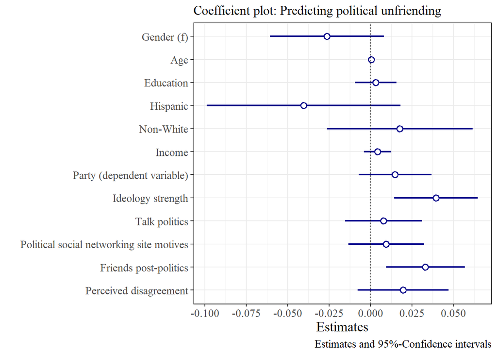

```r
# Use plot_summs for easy & pretty coefficient plotting
lm_fit %>%
  plot_summs(
    scale = TRUE,
    colors = "darkblue",
    # Again omit Intercept in plot
    omit.coefs = "(Intercept)",
    # Rename coefficients
    coefs = c(
      "Gender (f)" = "gender",
      "Age" = "age",
      "Education" = "educ",
      "Hispanic" = "hisp",
      "Non-White" = "nonwhite",
      "Income" = "statedinc",
      "Party (dependent variable)" = "party3",
      "Ideology strength" = "ideostrength",
      "Talk politics" = "talkpol",
      "Political social networking site motives" = "polfbmotiv",
      "Friends post-politics" = "friendspostpol",
      "Perceived disagreement" = "disagree"
    )
  ) +
  # Set breaks and limits of x-axis
  scale_x_continuous(breaks = seq(-0.1, 0.1, 0.025),) +
  # Some labels
  labs(
    x = "Estimates",
    y = "",
    title = "Coefficient plot: Predicting political unfriending",
    caption = "Estimates and 95%-Confidence intervals"
  ) +
  # Styling
  theme_bw() +
  theme(
    text = element_text(
      family = "serif",
      colour = "black",
      size = 14
    ),
    plot.title = element_text(size = 13)
  )
```

4. Run `lm` models for all possible combinations of covariates from the original model and store the estimates. Then, provide visual evidence how the estimates for the four key predictors of interest (linked to H1A, H1B, H2, and H3) vary across those specifications, and briefly discuss your findings. [3 points]

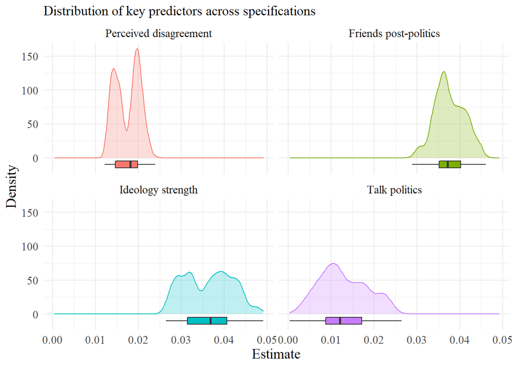

```r
# Use function from lecture to fit all possible specifications given a set of variables
combn_models <- function(depvar, covars, data) {
  combn_list <- list()
  for (i in seq_along(covars)) {
    combn_list[[i]] <- combn(covars, i, simplify = FALSE)
  }
  combn_list <- unlist(combn_list, recursive = FALSE)
  # function to generate formulas
  gen_formula <- function(covars, depvar) {
    form <-
      as.formula(paste0(depvar, " ~ ", paste0(covars, collapse = "+")))
    form
  }
  # generate formulas
  formulas_list <-
    purrr::map(combn_list, gen_formula, depvar = depvar)
  # run models
  models_list <- purrr::map(formulas_list, lm, data = data)
  models_list
}

# Store combinations in list
models_list <-
  combn_models(
    depvar = "unfriendscale",
    covars = c(
      "gender",
      "age",
      "educ",
      "hisp",
      "nonwhite",
      "statedinc",
      "party3",
      "ideostrength",
      "talkpol",
      "polfbmotiv",
      "friendspostpol",
      "disagree"
    ),
    data = bode_pew_data
  )

# Labels for plotting
facet_labels <- c(
  ideostrength = "Ideology strength",
  talkpol = "Talk politics",
  friendspostpol = "Friends post-politics",
  disagree = "Perceived disagreement"
)

# Extract coefficients of predictors across all specifications and store into new tibble
models_hyp_coef <- tibble(models = models_list %>% pluck()) %>%
  # Extract coefficients
  mutate(
    ideostrength = map_dfr(models, ~ coefficients(.x) %>% pluck())$ideostrength,
    talkpol = map_dfr(models, ~ coefficients(.x) %>% pluck())$talkpol,
    friendspostpol = map_dfr(models, ~ coefficients(.x) %>% pluck())$friendspostpol,
    disagree = map_dfr(models, ~ coefficients(.x) %>% pluck())$disagree,
  ) %>%
  # Drop models columns
  select(-models)

models_hyp_coef %>%
  # Convert to longer table format
  pivot_longer(cols = everything(),
               names_to = "coef",
               values_to = "value") %>%
  # Drop NA coefficient values
  drop_na(value) %>%
  # Plot coefficients
  ggplot(aes(x = value,
             y = -10,)) +
  # Adding Boxplot underneath density curves
  geom_boxplot(aes(fill = coef), width = 10) +
  # Plotting density plot for each predictor
  geom_density(aes(x = value,
                   fill = coef,
                   color = coef),
               alpha = 0.25,
               inherit.aes = FALSE) +
  facet_wrap( ~ coef, labeller = as_labeller(facet_labels)) +
  # Some styling
  theme_minimal() +
  theme(
    text = element_text(
      family = "serif",
      color = "black",
      size = 14
    ),
    plot.title = element_text(size = 13),
    legend.position = "none"
  ) +
  # Again labels
  labs(y = "Density",
       x = "Estimate",
       title = "Distribution of key predictors across specifications")
```

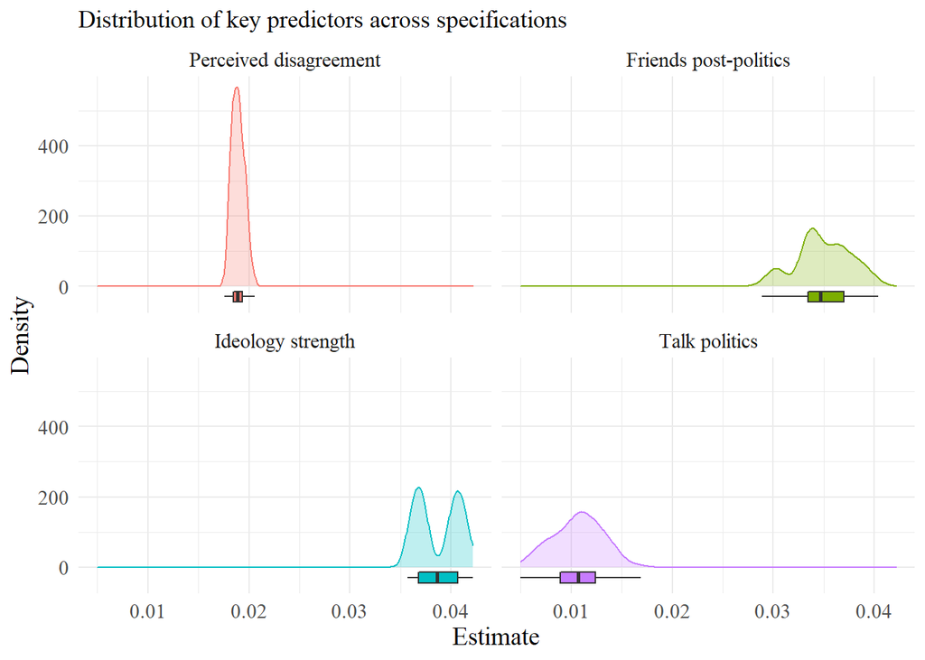

```r
# DETOUR
# Second Plot that includes at least ALL four of the key predictors
tibble(models = models_list %>% pluck()) %>%
  # Filter for models that contain ALL four key predictors
  filter(map_lgl(models,
                 ~ all(
                   c("ideostrength", "talkpol", "friendspostpol", "disagree") %in%
                     (.x %>%
                        coef() %>%
                        names())
                 ))) %>%
  # Extract coefficients
  mutate(
    ideostrength = map(models, ~ coefficients(.x) %>% pluck("ideostrength")) %>% unlist(),
    talkpol = map(models, ~ coefficients(.x) %>% pluck("talkpol")) %>% unlist(),
    friendspostpol = map(models, ~ coefficients(.x) %>% pluck("friendspostpol")) %>% unlist(),
    disagree = map(models, ~ coefficients(.x) %>% pluck("disagree")) %>% unlist(),
  ) %>%
  # Drop models columns
  select(-models) %>%
  # Convert to longer table format
  pivot_longer(cols = everything(),
               names_to = "coef",
               values_to = "value") %>%
  # Plot coefficients
  ggplot(aes(x = value,
             y = -30,)) +
  # Adding Boxplot underneath density curves
  geom_boxplot(aes(fill = coef), width = 30) +
  # Plotting density plot for each predictor
  geom_density(aes(x = value,
                   fill = coef,
                   color = coef),
               alpha = 0.25,
               inherit.aes = FALSE) +
  facet_wrap( ~ coef, labeller = as_labeller(facet_labels)) +
  # Some styling
  theme_minimal() +
  theme(
    text = element_text(
      family = "serif",
      color = "black",
      size = 14
    ),
    plot.title = element_text(size = 13),
    legend.position = "none"
  ) +
  # Again labels
  labs(y = "Density",
       x = "Estimate",
       title = "Distribution of key predictors across specifications")
```

What we observe is that `Friends post-politics (H2)` and `Talk politics (H1B)` are roughly normal distributed with the latter having a higher variance. `Perceived disagreement (H3)` and `Ideology strength (H1A)`, however, show a bimodal distribution, since we can observe two ‘peaks’. We can also observe that the estimates of `perceived disagreement (H3)` and `Talk politics (H1B)` are on average smaller than for the other two variables. Since these distributions neglect the significance of the coefficients across the specifications, we cannot infer much about the effects from these plots.

Further, we get slightly different results if we only include those models that incorporate at least **all** four of the key predictors. Especially for `Perceived disagreement (H3)`, this could mean that there might be some effects between the predictor variables. (see below)

5. Run a specification curve analysis for one of the four effects of interest. When doing so, come up with (a) an alternative measure of the response (can be just a transformation of the original measure), (b) an alternative key predictor measure (can be just a transformation of the original measure), and (c) different subsets of the data. More plausible criteria to generate alternative specifications are possible. Briefly discuss the results. [4 points]

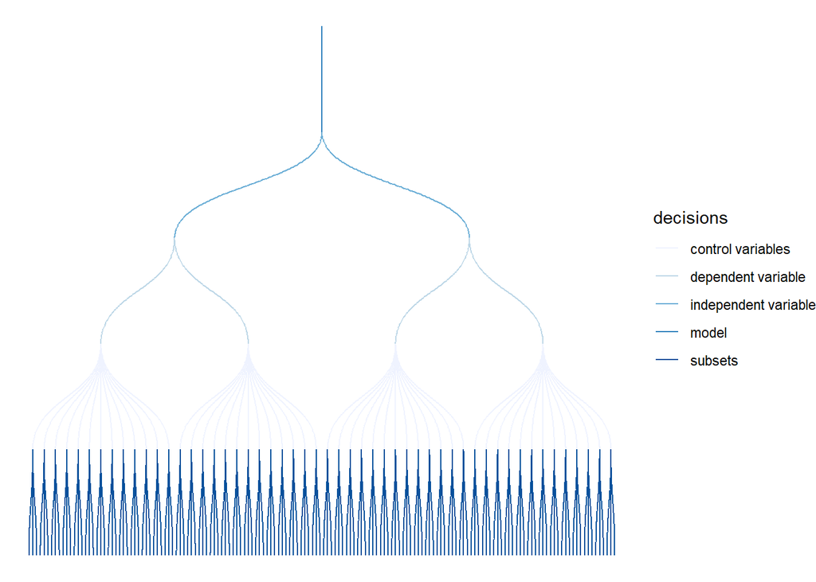

```r
# Calculate unfriendscale mean for subsetting
mean_unfriendscale <- bode_pew_data %>%
  summarise(mean = mean(unfriendscale, na.rm = TRUE)) %>%
  pull(mean)

# Create additional column `language` for subsetting of data in spec. curve analysis
bode_pew_data_spec_curve <- bode_pew_data %>%
  mutate(
    language = case_when(lang == 1 ~ "English", lang == 2 ~ "Spanish"),
    # Add dummy response variable with mean as divider
    unfriendscale_highlow = case_when(unfriendscale > mean_unfriendscale ~ 1, TRUE ~ 0)
  )

results <- run_specs(
  df = bode_pew_data_spec_curve,
  # Response variables
  y = c("unfriendscale", "unfriendscale_highlow"),
  # Alternative measure for predictor is squared
  x = c("ideostrength", "I(ideostrength^2)"),
  model = c("lm"),
  controls = c(
    "gender",
    "age",
    "educ",
    "hisp",
    "nonwhite",
    "statedinc",
    "party3",
    "polfbmotiv",
    "disagree",
    "talkpol",
    "friendspostpol"
  ),
  # Use language variable for subsetting
  subsets = list(language = unique(
    na.omit(bode_pew_data_spec_curve$language)
  ))
)

# Plot decision tree
plot_decisiontree(results, legend = TRUE)
```

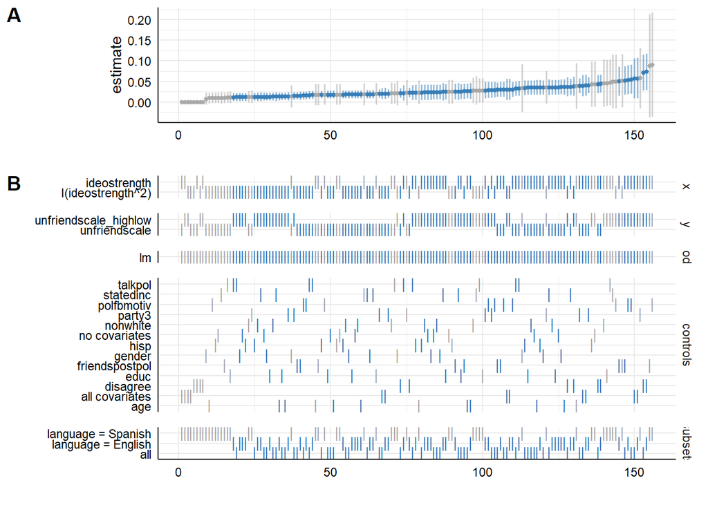

```r
# Plot specifications
plot_specs(results,
           rel_heights = c(4, 8))
```

It becomes obvious that for the dummy response variable `unfriendscale_highlow`, we get the highest significant estimates. This dummy is equal to 1 if the original `unfriendscale` value is bigger than its mean over all observations. Otherwise its value is 0.

Further, we can see that overall when comparing `ideostrength` and `ideostrength^2`, estimates are smaller for the squared measure. Therefore, it might be better to stick with the unsquared measure when deriving a *best* specification.

Interestingly, we find that even though the highest estimates are for the `Spanish` subset, none of these specifications is significant. That is very likely to be a consequence of the low number of observations for the `Spanish` subset (N = 114) when compared to the `English` subset (N = 2139).

### Task 2 - Predicting y [3 points in total]

It’s Friday evening and your somewhat nerdy friend visits you in your apartment. In her luggage she has a USB stick, on which you find the file `PrEdIcTiOn.csv`. She explains that her boss gave her this stick today together with the following task:

*The dataset contains one response variable `y` and 10 predictor variables `c1` to `c10`. There are various plausible explanations for the `y` values using the other variables in the dataset, but one of them is the most plausible of all. Provide the best explanation or prediction of `y` using one, several, or all predictors at once. In the end, provide an explanation of how the `y` values were generated (some noise will likely be part of the story)!*

You decide to help your friend because she’s promised to help you with your public policy assignment in return. What is your solution?

```r
# Read csv and scale / centre numeric variables
prediction_data <-
  read.csv("PrEdIcTiOn.csv") %>% mutate(across(where(is.numeric), scale))

# Again fit all possible specifications and store them into a list
pred_models_list <-
  combn_models("y",
               c("c1", "c2", "c3", "c4", "c5", "c6", "c7", "c8", "c9", "c10"),
               prediction_data)

best_model_fit <- tibble(model = pred_models_list) %>%
  mutate(# Compute adjusted R2 for all models and store them in new column
    r2_adj = map(model, ~ summary(.x)$adj.r.squared) %>% unlist()) %>%
  # Filter for the model with the highest adjusted R2 (highest explained variance while account for number of predictors)
  arrange(desc(r2_adj)) %>%
  select(model) %>%
  pluck(1) %>%
  pluck(1)

# Plot coefficient table to summarize best model specification
modelsummary(
  statistic = NULL,
  models = list(" " = best_model_fit),
  title = "Model specification with highest R2 Adjusted",
  fmt = "%.2f",
  coef_omit = "(Intercept)",
  gof_omit = "Log|BIC|F",
  estimate = c("{estimate} ({std.error}){stars}"),
  notes = list('+ p < 0.1, * p < 0.05, ** p < 0.01, *** p < 0.001')
) %>%
  kable_classic(full_width = T, html_font = "serif") %>%
  row_spec(9, extra_css = "border-top: 3px solid", hline_after = TRUE)
```

Model specification with highest R2 Adjusted

| c1 | -0.31 (0.02)*** |
| --- | --- |
| c2 | 0.06 (0.01)*** |
| c3 | 0.08 (0.01)*** |
| c4 | 0.01 (0.01) |
| c5 | 0.13 (0.01)*** |
| c6 | -0.01 (0.01) |
| c8 | 0.34 (0.02)*** |
| c9 | 0.20 (0.01)*** |
| Num.Obs. | 825 |
| R2 | 0.938 |
| R2 Adj. | 0.937 |
| AIC | 65.8 |

+ p < 0.1, * p < 0.05, ** p < 0.01, *** p < 0.001

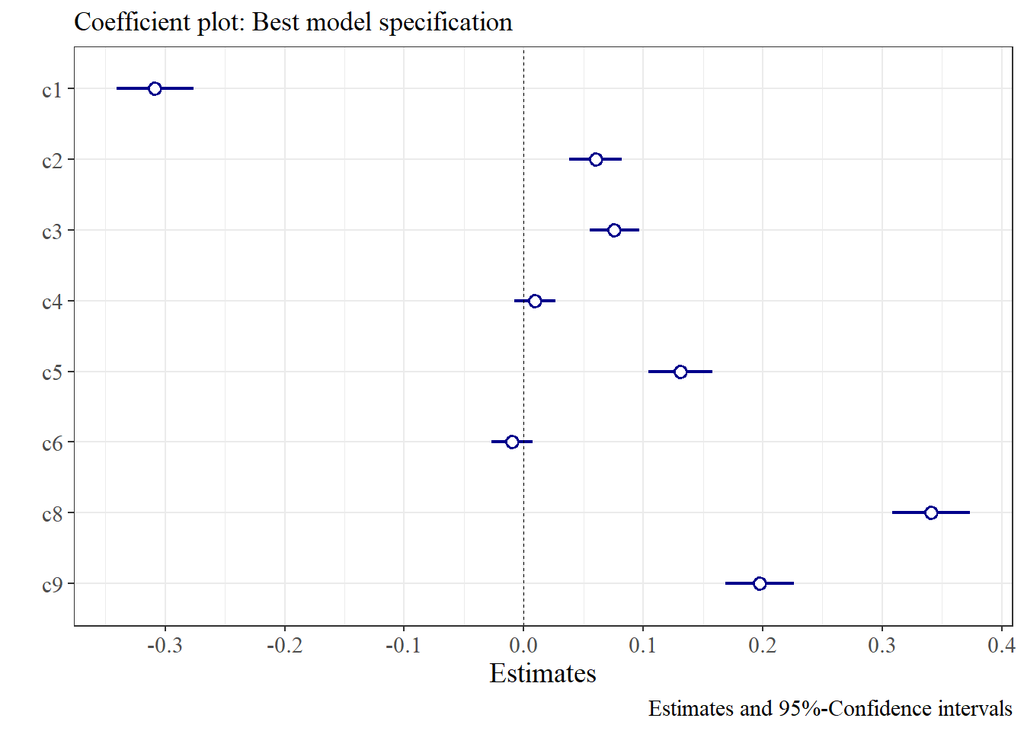

```r
# Additionally plot coefficient plot from Task 1 to visualize effect sizes and standard error
plot_summs(best_model_fit,
           colors = "darkblue") +
  # Set breaks and limits of x-axis
  scale_x_continuous(breaks = seq(-0.4, 0.4, 0.1), ) +
  # Some labels
  labs(
    x = "Estimates",
    y = "",
    title = "Coefficient plot: Best model specification",
    caption = "Estimates and 95%-Confidence intervals"
  ) +
  # Styling
  theme_bw() +
  theme(
    text = element_text(
      family = "serif",
      colour = "black",
      size = 14
    ),
    plot.title = element_text(size = 13)
  )
```

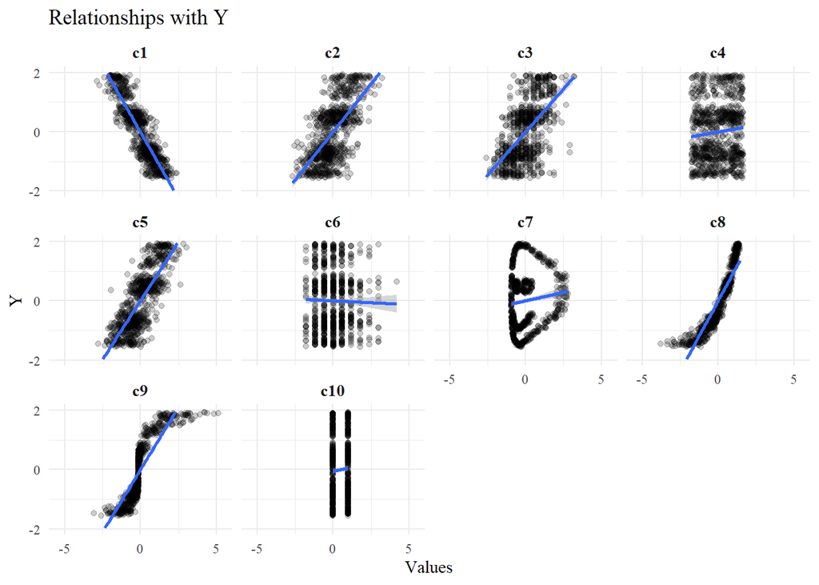

```r
#From the following scatterplots we can also clearly see that only the highly significant predictors from our model show a clear association with Y, which corroborates our findings
prediction_data %>%
  pivot_longer(c1:c10, names_to = "predictors", values_to = "values") %>%
  # Relevel factors to sort facetted plots
  mutate(predictors = fct_relevel(
    predictors,
    c("c1", "c2", "c3", "c4", "c5", "c6", "c7", "c8", "c9", "c10")
  )) %>%
  ggplot(aes(x = values,
             y = y)) +
  geom_point(alpha = 0.2) +
  geom_smooth(method = lm) +
  scale_x_continuous(breaks = c(-5, 0, 5),
                     limits = c(-5.5, 5.5)) +
  scale_y_continuous(breaks = c(-2, 0, 2),
                     limits = c(-2, 2)) +
  facet_wrap(~ predictors) +
  labs(x = "Values",
       y = "Y",
       title = "Relationships with Y") +
  theme_minimal() +
  theme(text = element_text(family = "serif", ),
        strip.text.x = element_text(
          size = 10,
          face = "bold"))
```

We can see that the linear model that includes all variables except c7 and c10 has the highest adjusted R2 across all specifications. The adjusted R2 of 0.937 indicates that this specification explains 93.7% of the variance in `y`.

The predictors c1, c2, c3, c5, c8 and c9 are all highly significant with p < 0.001. c4 and c6, however, are not significant.

We can also see (since we centered and standardized our data) that c8, c9 seem to have the largest positive effect sizes on y, while c1 has the largest negative effect size.

The additional scatterplots that shows the individual relatonships of the predictors with Y again corroborate our model findings, since only the significant variables show a clear association with Y.

*Note:* During calculation and sorting of the adj. r2 of the models, it seemed like there are multiple models with the same r2 metric. However, this is because dplyr silently rounds this value during sorting and the r2 values actually differ when one considers more decimals. Therefore, there is a *true* maximum adj. r2 value.